# PHYS 210 Day 07

### 2026 - 10 - 05

Agenda:

1. Announcements: **Test 1 done** — results in PrairieLearn · **Practice Test 2 out tomorrow (Tue Oct 6)** · Test 2 window **Tue Oct 13 – Sat Oct 17** · Homework 07 + Preclass 08 due **Wed 9 am**
2. Preclass 07 Q&A: a question about Linux, then polling questions on plotting with Matplotlib
3. `plt.subplot()` vs `plt.subplots()`, `plt.plot(a, a, b)`, reading error traces in Jupyter
4. Group Worksheet 07

### Q: What does Linux do that modern interfaces can't? Is Linux something we must know in order to build programs?

For many (many) physics summer jobs or co-ops, you will be working in a Linux environment. At minimum we want you to have a starting point to build on. One of the strengths of Linux (or programming languages vs gui-based software) is the efficiency that you gain when doing a repetitive task.

**Example 1:** Physics 119 uses python instead of Excel, in part, because once you know how to build graphs in python it is only a few lines of code as opposed to multiple minutes of clicking on interface buttons to make a scatter plot, with error bars, and a best fit line.

### Example 2: Toddlers point. Adults use their words.

Pointing (Canvas, in a browser)

Words (a terminal)

1. Assignments → open *Homework 05*
2. Edit → change the due date → Save
3. Back → open *Preclass 06* → Edit → …
4. …and again for *Homework 06* and *Preclass 07*

```
$ ./shift_due.py --match "Homework|Preclass" --after 2026-09-28 --days 7
Homework 05    Mon Sep 28 -> Mon Oct 05
Preclass 06    Mon Sep 28 -> Mon Oct 05
Homework 06    Mon Oct 05 -> Mon Oct 12
Preclass 07    Mon Oct 05 -> Mon Oct 12
4 assignment(s) would change (dry run; add --apply)
$ ./shift_due.py ... --apply
```

A sentence can be **read, checked first (the dry run), repeated and shared**. Explaining a string of clicks requires lengthy descriptions or screenrecordings.

## Reading topics for Plotting with matplotlib

```
import matplotlib.pyplot as plt
plt.plot([1, 2, 3, 4], [1, 4, 9, 16])
```

- Line and point styles
- Errorbars
- Saving figures to files (e.g., png)
- Multiple plots with `subplot()`
- Histograms and bar plots
- Scatter plots (different point sizes & colours)
- 2-D arrays as pictures: `imshow`, `contourf`

**Poll Q1:** What happens when this code runs? (`import numpy as np` and `import matplotlib.pyplot as plt` were run first)

```
t = np.linspace(0, 4, 5)
y = np.exp(-t)[1:]
plt.plot(t, y, 'o-')
```

A) four points, drawn at the first four values of `t`  
B) four points, drawn at the last four values of `t`  
C) a `ValueError`: `t` and `y` do not have the same number of values  
D) an `IndexError`  
E) five points; the last `y` is 0

**Poll Q2:** `n, bins, patches = plt.hist(heights, 10)` draws a histogram of 200 values with 10 bins. What are `n` and `bins`?

A) `n` = the 10 bar heights (counts per bin), `bins` = the 11 bin edges  
B) `n` = 10 (the number of bins), `bins` = the 10 bar heights  
C) `n` = the 10 bin centres, `bins` = the 10 bar heights  
D) `n` and `bins` are both arrays with 10 entries  
E) `plt.hist` returns nothing — this line raises an error

### The same 30 numbers, three histograms

```
plt.hist(data, 4)     # 4 bins
plt.hist(data, 7)     # 7 bins
plt.hist(data, 12)    # 12 bins
```

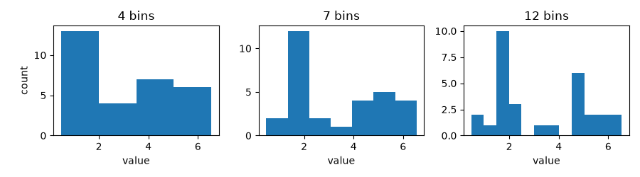

Same data, three different shapes: the bin count is a **plotting choice**, not a fact about the data.

### Cumulative histogram: the same 30 numbers, the same three bin choices

```
plt.hist(data, 4,  cumulative=True, density=True)
plt.hist(data, 7,  cumulative=True, density=True)
plt.hist(data, 12, cumulative=True, density=True)
```

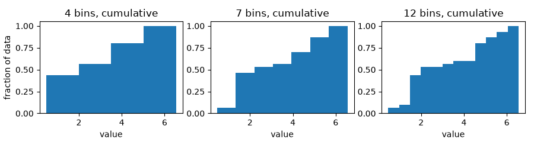

Each bar is "the fraction of the data up to here", so every choice of bins draws nearly the same S-curve.

### No bins at all: `plt.ecdf(data)`

```
plt.ecdf(data)     # needs Matplotlib 3.8 or newer
```

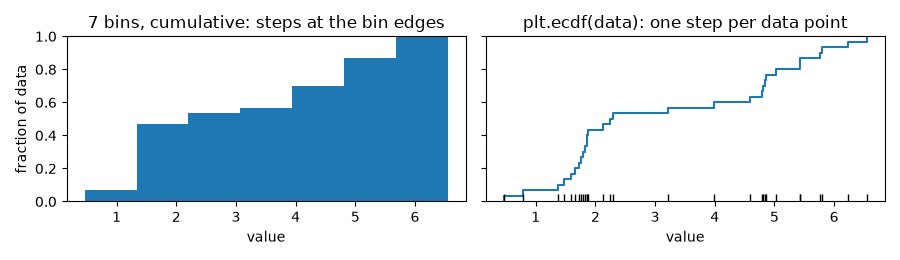

`plt.hist(..., cumulative=True)` still sorts the data into bins first, so its steps sit at equally spaced bin edges. `plt.ecdf` steps up by 1/N at every data point (N = 30 here): nothing to choose, nothing hidden.

```python
# Demo: the same 30 numbers, three bin choices, then cumulative, then the ECDF
import numpy as np
import matplotlib.pyplot as plt

rng = np.random.default_rng(3)
data = np.concatenate([rng.normal(2.0, 0.6, 18), rng.normal(5.0, 0.8, 12)])   # 30 values

fig, ax = plt.subplots(1, 3, figsize=(9, 2.5))
ax[0].hist(data, 4)
ax[1].hist(data, 7)
ax[2].hist(data, 12)
plt.show()

fig, ax = plt.subplots(1, 3, figsize=(9, 2.5))
ax[0].hist(data, 4,  cumulative=True, density=True)
ax[1].hist(data, 7,  cumulative=True, density=True)
ax[2].hist(data, 12, cumulative=True, density=True)
plt.show()

plt.figure(figsize=(5, 2.5))
plt.ecdf(data)          # one step per data point, no bins
plt.show()
```

### A plot is an argument

**Edward R. Tufte, *The Visual Display of Quantitative Information*** (Graphics Press, 1983; 2nd edition 2001)

- "Above all else show the data."
- Every choice you make in a plot (bins, axis range, markers, colours) changes what the reader sees. Make each choice on purpose.
- Today's example: the ECDF shows every data point, with no bins to choose.

### seaborn: statistical plots on top of Matplotlib

- `import seaborn as sns`, then one call per plot type: `sns.histplot`, `sns.ecdfplot`, `sns.violinplot`, `sns.pairplot`, …
- Every call draws on Matplotlib axes, so `plt.xlabel()`, `plt.savefig()` and `ax=ax[0]` from `plt.subplots()` still work
- Gallery: [seaborn.pydata.org/examples](https://seaborn.pydata.org/examples/index.html)

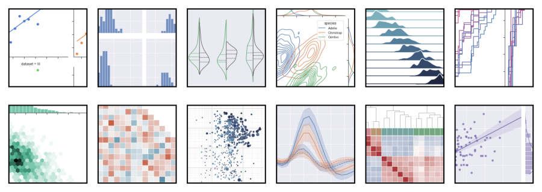

### Q. Can you review `plt.subplot()` and `plt.subplots()`?

### `plt.subplot()`

`plt.subplot()` lets you make composite figures with more than one plot set side-by-side or one above another. The parameters are three numbers (e.g., `plt.subplot(2,3,1)` ) where

- The first number (2) is how many rows of subplots there are,
- The second number (3) is how many columns there are
- And then the third number (1) is the index of the subplot you are currently plotting. This counting is like reading in English left to right and then proceeding downward: Bizarrely, the counting on this starts at 1, not 0.

For any one figure with subplots, the first two numbers should always be the same. Usage would look something like:

```
plt.subplot(2, 2, 1) # top-left
plt.plot(x1, y1)
plt.subplot(2, 2, 2) # top-right
plt.plot(x2,  y2)
plt.subplot(2, 2, 3) # bottom-left
plt.plot(x3, y3)
...
```

### `plt.subplots()`, which counts from 0 like most other things in python

```
fig, ax = plt.subplots(1, 2)      # 1 row, 2 columns: ax[0] left, ax[1] right
ax[0].plot(x, y, 'ko', label='data')
ax[0].legend()                    # plt.something becomes ax[i].something
n, bins, patches = ax[1].hist(values, 8)
ax[1].set_xlabel('value')         # labels: ax[i].set_xlabel, not ax[i].xlabel
```

- One row or one column: `ax` is 1-D, so `ax[0]`, `ax[1]` (Homework 07 Task 4)
- A 2 × 3 grid: `ax` is 2-D, so `ax[0, 1]` = first row, second column

**Poll Q3:** In a 2 × 2 grid, which panel does `plt.subplot(2, 2, 3)` address?

| A) top-left | B) top-right |
| --- | --- |
| C) bottom-left | D) bottom-right |
| E) none — the index must start at 0 |  |

**Q.** How does it work when 3 lists/arrays are specified `plt.plot(a, a, b)`? https://matplotlib.org/stable/api/_as_gen/matplotlib.pyplot.plot.html

Let's start with what happens if you just use `plt.plot(b)`. When an argument is on its own, it gets interpreted as the `y` values and with `x` starting at 0, e.g., [0, 1, 2, 3]

```python
import numpy as np; import matplotlib.pyplot as plt
a = np.linspace(2, 5, 5)
plt.figure(figsize=(5, 2.4)); plt.plot(a); plt.show()
```

`plt.plot(a, a, b)`: First two arguments are taken as x and y values, so you get a vs a. The 3rd argument is by itself, so is interpreted as y values for a new graph.

```python
import numpy as np; import matplotlib.pyplot as plt
a = np.linspace(1, 4, 5)
b = 3*a
plt.figure(figsize=(5, 2.4)); plt.plot(a, a, b); plt.show()
```

### Homework 06: what the submissions showed

The tests passed almost everywhere. These three things they did not catch:

- **`r2` already holds r²:** after `r2 = X**2 + Y**2`, `np.exp(-r2**2)` is exp(−r⁴). Peak 1 and tiny corners, so the test passes. At (1, 1): `np.exp(-2)` = 0.135, but `np.exp(-4)` = 0.018
- **A comparison already is a mask:** `arr % 5 == 0` is a bool array. `np.where(arr % 5 == 0, True, False)` gives the same array. Use it directly: `arr[arr % 5 == 0]` gives `[10 20]`
- **`linspace` keeps the end point, `arange` does not:** `np.arange(-3, 3, 0.003)` has 2000 points but stops at 2.997. `np.linspace(-3, 3, 2000)` stops at 3.0

**Same debugging routine as always** → next slide

```python
# Demo: a bug two functions deep
import numpy as np

def decay(t, tau):
    return np.exp(-t / tau)

def table(times, tau):
    values = decay(times, tau)
    return values[len(times)]

table(np.arange(5), 2.0)
```

### The wall of red: what it says

```
IndexError                                Traceback (most recent call last)
Cell In[1], line 10
      6 def table(times, tau):
      7     values = decay(times, tau)
      8     return values[len(times)]
      9
---> 10 table(np.arange(5), 2.0)

Cell In[1], line 8, in table(times, tau)
      6 def table(times, tau):
      7     values = decay(times, tau)
----> 8     return values[len(times)]

IndexError: index 5 is out of bounds for axis 0 with size 5
```

* Last line: **what** went wrong. Arrows `---->`: the line that was running in each block.

### Reading an error trace, in this order

1. **Last line first**: the error type and its message
2. **The block that is your own cell** (`Cell In[…], line N`): the arrow shows the line that was running
3. **The deepest block is where it crashed** — the cause may be in the line that called it. Check the values just above
4. **Library code** (`.../matplotlib/...`) is almost never the bug; your arguments are
5. The type is a clue: `NameError` (typo, or you did not run that cell), `TypeError`, `ValueError` (right kind of thing, wrong shape or value), `IndexError`, `SyntaxError` (no trace, a `^` marks the spot)

## Test 1 is done — Practice Test 2 tomorrow, Test 2 next week

- **Test 1** results: in the **Gradebook** of PrairieLearn (Canvas → PHYS 210 → **PrairieLearn** in the left menu)
- **Practice Test 2** goes live **Tue Oct 6**: the same format and question styles as Test 2, unlimited attempts, instant feedback
- **Test 2**: a 50-minute test at ORCA, window **Tue Oct 13 – Sat Oct 17**, covers Days 05–08: arrays, plotting and `while` loops (dictionaries come on Test 3)

## Changes in Test 2

**Test 1: a near-perfect record.** 103 of 110 of you scored 100 %, and most of you were done in a fraction of the time. Well done!

**What changes on Test 2**

- **More variants.** Each question comes in more variants than on Test 1, so what carries over is the method, not the answer
- **A lock halfway through.** Part 1 (predict and interpret) becomes **read-only** when you continue to Part 2 (write code). Check Part 1 before you move on
- **Practice Test 2** has the same two parts, and every new attempt gives you a new set of questions

# The rest of today, and before you leave

- **Group Worksheet 07** (plotting): link on Canvas; one driver per group, swap each task; check-out with a TA when done
- **Homework 07** (short: five plotting tasks on one data set) due **Wed Oct 7, 9 am**. **Restart Kernel and Run All Cells before you export**; upload the `.ipynb` **and** `decay_summary.png`
- **Preclass 08 (dictionaries, tuples and `while` loops)** due **Wed Oct 7, 9 am**
- **Practice Test 2** is out tomorrow: do it once in 50 minutes before Oct 13